# Practica 1

Olivares García Héctor

# ENOE

La Encuesta Nacional de Ocupación y Empleo (ENOE) es la principal fuente de información sobre el mercado laboral mexicano al ofrecer datos mensuales y trimestrales de la fuerza de trabajo, la ocupación, la informalidad laboral, la subocupación y la desocupación.

El objetivo de esta práctica es replicar las estimaciones del archivo `2020_trim_4_Nacional.xls` correspondientes al cuarto trimestre de 2020 de la ENOE.

La documentación, tabulados y microdatos se pueden encontrar en el siguiente enlace https://www.inegi.org.mx/programas/enoe/15ymas/

Resultados del cuarto trimestre de 2020 https://www.inegi.org.mx/contenidos/programas/enoe/15ymas/doc/enoe_n_presentacion_ejecutiva_trim4.pdf

## DISEÑO MUESTRAL

El diseño muestral de la ENOE se carácteriza por ser probabilístico, por lo cual los resultados obtenidos de la encuesta se generalizan a toda la población, a su vez es bietápico, estratificado y por conglomerados, donde la unidad última de observación es la persona que al momento de la entrevista tenga 15 años cumplidos o más de edad.

https://www.inegi.org.mx/contenidos/productos/prod_serv/contenidos/espanol/bvinegi/productos/nueva_estruc/702825190613.pdf

## BASE DE DATOS

La base de datos de la ENOE está conformada por cinco tablas:

1. Vivienda
2. Hogar
3. Sociodemográfico
4. Cuestionario de ocupación y empleo parte I
5. Cuestionario de ocupación y empleo parte II

Para replicar las estimaciones del archivo `2020_trim_4_Nacional.xls` se trabajará con la base Sociodemográfica `ENOEN_SDEMT420.csv`

https://www.inegi.org.mx/contenidos/programas/enoe/15ymas/doc/enoe_n_fd_c_bas_amp.pdf

## VARIABLES DE INTERÉS

La base Sociodemográfico `ENOEN_SDEMT420.csv` consta de 110 variables de las cuales las siguentes son de nuestro interés:

- **ca**: Registro por panel.
- **upm**: Número de la unidad primaria de muestreo.
- **est_d_tri**: Número del estrato de diseño trimestral.
- **fac_tri**: Ponderador que permite obtener los resultados trimestrales.
- **clase1**: Clasificación de la población en **PEA** (Población económicamente activa) y **PNEA** (Población no económicamente activa).
- **clase2**: Clasificación de la población en **PO** (ocupada) y **PD** (desocupada), **D** (disponible) y **ND** (no disponible).
- **sex**: Sexo
- **r_def**: Resultado definitivo de la entrevista.
- **c_res**: Condición de residencia.
- **eda**: edad.

### CONSIDERACIONES

- Las variables clase1 y clase2 son variables precodificadas. Para el uso de las variables se debe aplicar el siguiente criterio: R_DEF = 00 (Entrevista completa), C_RES = 1 o 3 (Residente habitual o Nuevo residente) y EDAD 15 a 98 AÑOS.
- Para el cálculo de las precisiones estadísticas ya sea para el periodo mensual o trimestral, se debe considerar como unidad primaria de muestreo, los campos CA+UPM, lo cual permite identificar de manera única cada UPM.

```r
base <- read.csv('ENOEN_sdemt420.csv', header=TRUE, sep=",", na.strings="NA", dec=".") %>%
  dplyr::filter(ï..r_def==0 & (c_res==1 | c_res==3) & (eda>=15 & eda<=98)) %>%
  mutate(ca_upm = paste(ca, upm, sep="_")) %>%
  select(ca_upm,est_d_tri, fac_tri, clase1, clase2,sex)

base$clase1 <- factor(base$clase1, labels= c("PEA","PNEA"))
base$clase2 <- factor(base$clase2, labels= c("PO","PD","D","ND"))
base$sex <- factor(base$sex, labels= c("Hombre","Mujer"))
```

### APLICACION CON SURVEY

```r
options(survey.lonely.psu="adjust")
ENOE <- svydesign(data = base,
                  strat = ~est_d_tri,
                  id = ~ca_upm, nest=TRUE,
                  weight = ~fac_tri)

total_c1 <- svytotal(~clase1, ENOE) %>% as.data.frame()
total_c2 <- svytotal(~clase2, ENOE) %>% as.data.frame()

intc_c1 <- confint(svytotal(~clase1, ENOE), df=degf(ENOE),level=0.9) %>% as.data.frame()
intc_c2 <- confint(svytotal(~clase2, ENOE), df=degf(ENOE),level=0.9) %>% as.data.frame()
```

#### PEA Y PNEA (CLASE1)

| clase1 | Total | SE | LIIC | LSIC | Proporcion |
| --- | --- | --- | --- | --- | --- |
| PEA | 55880916 | 324644.2 | 55346897 | 56414935 | 0.574927 |
| PNEA | 41315621 | 284277.2 | 40848003 | 41783239 | 0.425073 |

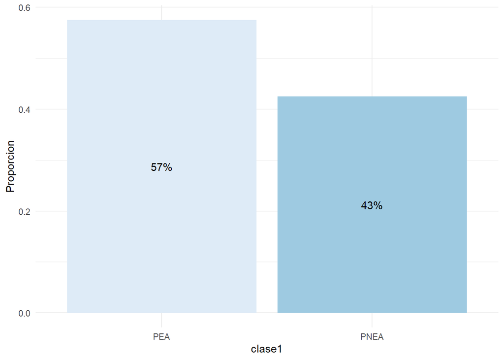

```
##                                        total     SE
## interaction(clase1, sex)PEA.Hombre  34223853 227321
## interaction(clase1, sex)PNEA.Hombre 11929614 143370
## interaction(clase1, sex)PEA.Mujer   21657063 185665
## interaction(clase1, sex)PNEA.Mujer  29386007 218913
```

#### PO y PD, D y ND (CLASE 2)

| clase2 | Total | SE | LIIC | LSIC | Proporcion |
| --- | --- | --- | --- | --- | --- |
| PO | 53331429 | 315861.67 | 52811857 | 53851001 | 0.5486968 |
| ND | 32387309 | 259763.60 | 31960015 | 32814603 | 0.3332146 |
| D | 8928312 | 143232.75 | 8692703 | 9163921 | 0.0918583 |
| PD | 2549487 | 74746.07 | 2426535 | 2672439 | 0.0262302 |

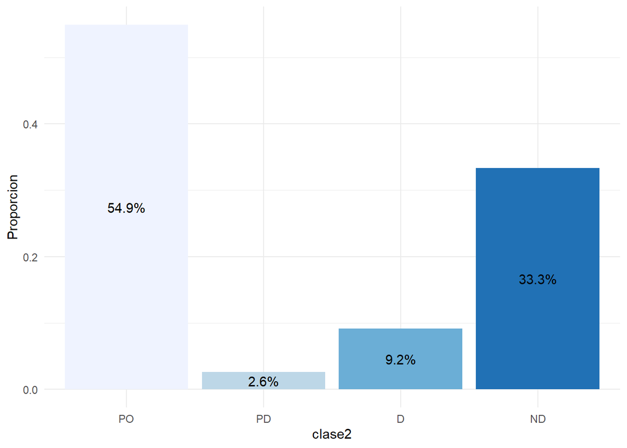